# SEVPlantBiomass_16Aug17

AJ

8/16/2017

## Background

Several long-term studies at the Sevilleta LTER measure net primary production (NPP) across ecosystems and treatments. Net primary production is a fundamental ecological variable that quantifies rates of carbon consumption and fixation. Estimates of NPP are important in understanding energy flow at a community level as well as spatial and temporal responses to a range of ecological processes. Above-ground net primary production (ANPP) is the change in plant biomass, including loss to death and decomposition, over a given period of time. To measure this change, vegetation variables, including species composition and the cover and height of individuals, are sampled up to three times yearly (winter, spring, and fall) at permanent plots within a study site. Sevilleta LTER dataset 157 includes cover, height, and dry biomass measurements obtained through destructive harvesting. These species are always harvested from habitat comparable to the plots in which they were recorded.

## Purpose

The following R code utilizes volume (cover*height) and weight data from Sev dataset 157 to create regressions which can be used to estimate seasonal biomass for plant species across the Sevilleta.

## Special Notes

Eventually, this script will output a report for each species for which we have destructive harvest biomass data. This report will describe the optimal model for estimating biomass of each species. Possible predictor variables will include:  
-individual plant volume (height*cover) -site at which plant occurs -season (or day of year) during which plant was observed -treatment (burned or unburned) -*year during which destructive harvest sample was collected

**note*: If year of collection plays a significant role in predicting biomass, antecedent precipitation, temperature, or previous season’s biomass should be considered when predicting biomass for that species

### Step 1: Preparing the data

SEV dataset 157 (version 20161218) is used here.

The data look like this:

| Year | Season | Date | Site | Treatment | Species | Cover | Height | Live_Weight | Volume | SiteCluster |
| --- | --- | --- | --- | --- | --- | --- | --- | --- | --- | --- |
| 1999 | 1 | 2/4/1999 | C | C | ARDI5 | 0.10 | 14 | 0.04 | 1.4 | L |
| 1999 | 1 | 2/4/1999 | C | C | ARDI5 | 0.10 | 14 | 0.06 | 1.4 | L |
| 1999 | 1 | 2/4/1999 | C | C | ARDI5 | 0.10 | 21 | 0.10 | 2.1 | L |
| 1999 | 1 | 2/4/1999 | C | C | ARDI5 | 0.25 | 20 | 0.37 | 5.0 | L |
| 1999 | 1 | 2/4/1999 | C | C | ARDI5 | 0.25 | 20 | 0.29 | 5.0 | L |
| 1999 | 1 | 2/4/1999 | C | C | ARDI5 | 0.25 | 18 | 0.27 | 4.5 | L |

## Model Construction

### Base model

```r
# Construct base model
base.model <- lm(Live_Weight ~ 0 + Volume, data=sp.sub)
summary(aov(base.model))
```

```
##            Df Sum Sq Mean Sq F value Pr(>F)
## Volume      1 314085  314085    2570 <2e-16 ***
## Residuals 509  62200     122
## ---
## Signif. codes:  0 '***' 0.001 '**' 0.01 '*' 0.05 '.' 0.1 ' ' 1
## 18 observations deleted due to missingness
```

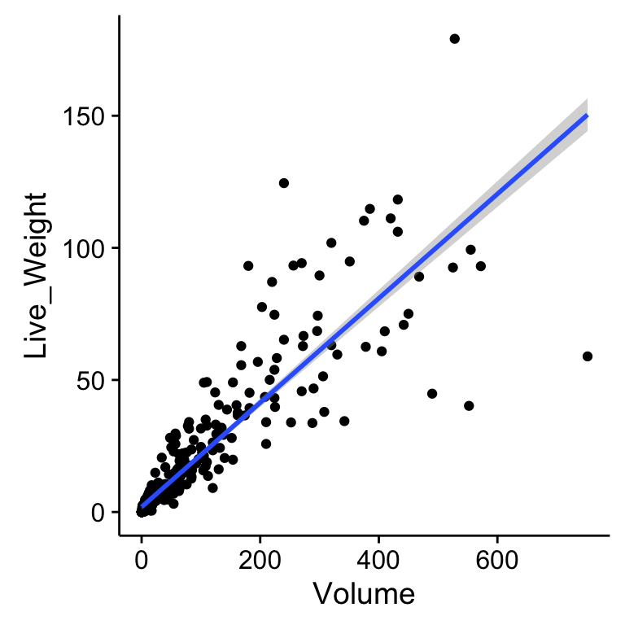

```r
# Construct full linear model
full.model <- lm(Live_Weight ~ 0 +
                   Volume*Year +
                   Volume*SiteCluster +
                   Volume*Season +
                   Volume*Treatment, data=sp.sub)
summary(aov(full.model))
```

```
##                     Df Sum Sq Mean Sq  F value   Pr(>F)
## Volume               1 314085  314085 5733.170  < 2e-16 ***
## Year                 7   4278     611   11.155 4.00e-13 ***
## SiteCluster          1     90      90    1.646 0.200061
## Season               2   1720     860   15.701 2.46e-07 ***
## Treatment            1    725     725   13.229 0.000305 ***
## Volume:Year          6   6802    1134   20.693  < 2e-16 ***
## Volume:SiteCluster   1   2642    2642   48.227 1.22e-11 ***
## Volume:Season        2  18954    9477  172.989  < 2e-16 ***
## Volume:Treatment     1    254     254    4.645 0.031632 *
## Residuals          488  26735      55
## ---
## Signif. codes:  0 '***' 0.001 '**' 0.01 '*' 0.05 '.' 0.1 ' ' 1
## 18 observations deleted due to missingness
```

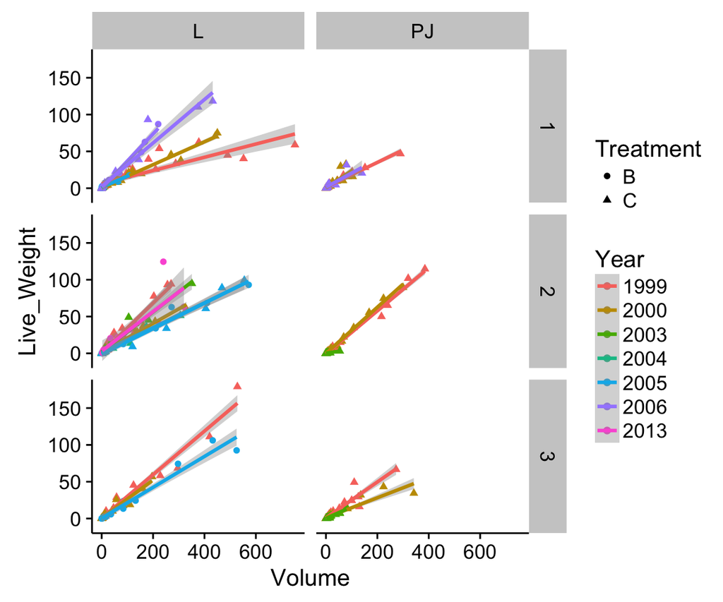

```r
# Construct year linear model
year.model <- lm(Live_Weight ~ 0 + Volume*Year, data=sp.sub)
summary(aov(year.model))
```

```
##              Df Sum Sq Mean Sq  F value   Pr(>F)
## Volume        1 314085  314085 3062.375  < 2e-16 ***
## Year          7   4278     611    5.959 1.13e-06 ***
## Volume:Year   6   7051    1175   11.458 5.11e-12 ***
## Residuals   496  50871     103
## ---
## Signif. codes:  0 '***' 0.001 '**' 0.01 '*' 0.05 '.' 0.1 ' ' 1
## 18 observations deleted due to missingness
```

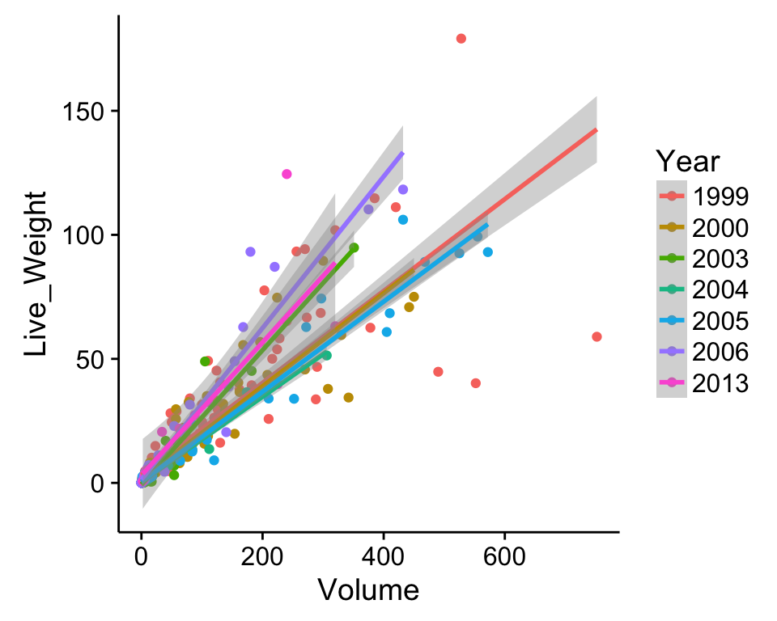